# Problema 4 - Checkpoint 3

## Introdução

Para esta análise usaremos uma amostra dados de dados da atividade global do github. Os dados brutos contém a contagem de quantas pessoas editaram arquivos com cada extensão de arquivo em cada dia de 2016 e 2017 no github. Não temos dados de todos os repositórios nem de todos os usuários, portanto estamos trabalhando com uma amostra.

## Conhecendo e Manipulando os Dados

O conjunto de dados é uma amostra de dados da atividade global do github, suas variáveis são: a extensão do arquivo, o dia do mês, o mês e o ano em que arquivos com essa extenção foram editados e o número de usuários que editaram os arquivos.

Os dados serão filtrados para que a amostra contenha apenas arquivos com extensões usadas por linguagens de programação, a seguir será analisado o gráfico que apresenta o comportamento da atividade de usuários de todas as linguagens.

```r
dados <- read.csv("github-users-committing-filetypes.csv")

unique(dados$file_extension)
```

```
##  [1] md      js      json    html    py      java    css     xml
##  [9] txt     yml     h       php     png     cpp     sh      rb
## [17] c       scss    cs      jpg     lock    go      ts      svg
## [25] gradle  csproj  rst     m       map     ttf     yaml    pbxproj
## [33] less    woff    eot     swift   cc      sql     gif     ico
## [41] config  pdf
## 42 Levels: c cc config cpp cs csproj css eot gif go gradle h html ... yml
```

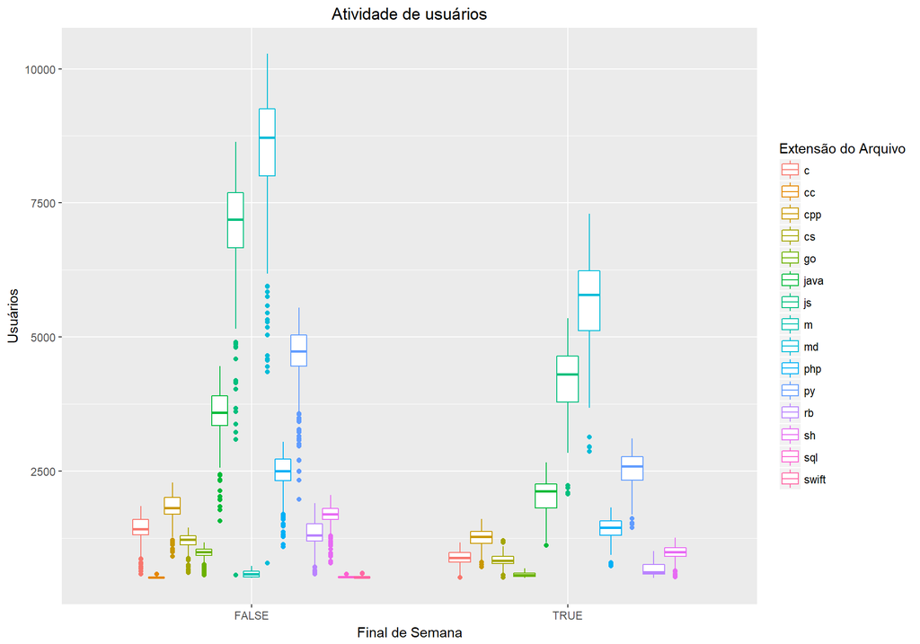

```r
not.language <- dados %>% filter(file_extension  %in% c("xml", "txt", "yml","png","h","scss", "jpg", "lock", "ts", "gradle","svg", "rst", "gif","ico","config","pdf","yaml", "html", "eot", "json", "less", "map", "pbxproj","ttf","woff", "css", "csproj"))

dados <- setdiff(dados, not.language)

dados <- dados %>% mutate(full_date = paste(month_day, the_month, the_year, sep = '-'))

dados <- dados %>% mutate(week_day= weekdays(as.Date(full_date,'%d-%m-%Y')))


dados.week <- dados %>% filter(week_day != "sábado" & week_day != "domingo")
dados.weekend <- dados %>% filter(week_day == "sábado" | week_day == "domingo")

dados.week$week_day = FALSE
dados.weekend$week_day = TRUE

dados = rbind(dados.week,dados.weekend)

rm(dados.week)
rm(dados.weekend)
rm(not.language)

names(dados)[7] <- "weekend"

plot_p1 <- dados %>%
  ggplot(aes(x = weekend, y = users, color = file_extension)) +
  geom_boxplot() +
  labs(title = "Atividade de usuários", x = "Final de Semana", y = "Usuários", color="Extensão do Arquivo") +
  theme(plot.title = element_text(hjust = 0.5))

plot_p1
```

Podemos observar que em geral a mediana das atividades de usuário nos dias de semana é maior que no final de semana, no entanto as variâncias (que podem ser inferidas analisando o tamanho de cada boxplot) das atividades nos dias de semana e nos finais de semana parecem estarem próximas sempre. Nesta primeira parte da análise iremos observar o comportamento da variância nos dias de semana e finais de semana para a linguagem de programação C.

## Variância em C

Hipótese: Foi suposto que a variância nos finais de semana seria menor do que nos dias de semana, dado que existem mais dados para os dias de semana (pois existem mais dias de semana do que finais de semana) e porque acreditamos que a atividade no final de semana, por ser geralmente menor, tenderia a ser mais homogênea.

```r
plot_p1 <- dados %>% filter(file_extension == "c") %>%
  ggplot(aes(x = weekend, y = users, fill = weekend)) +
  geom_boxplot() + scale_fill_manual(values=c("#999999", "#c17dd1")) +
  labs(title = "Atividade de usuários (C)", x = "Final de Semana", y = "Usuários", fill = "Final de Semana") +
  theme(plot.title = element_text(hjust = 0.5))

ggplotly(plot_p1,width = 800,height = 500)
```

```
## We recommend that you use the dev version of ggplot2 with `ggplotly()`
## Install it with: `devtools::install_github('hadley/ggplot2')`
```

[interactive chart not shown]

Por meio do gráfico de boxplot é possível notar que existe uma diferença significativa entre a variância nos dias de semana e finais de semana, tendo os dias de semana uma variância mais elevada. Porém como o conjunto de dados é uma amostra iremos realizar o procedimento de bootstrapping para confirmar se nossa conclusão é válida.

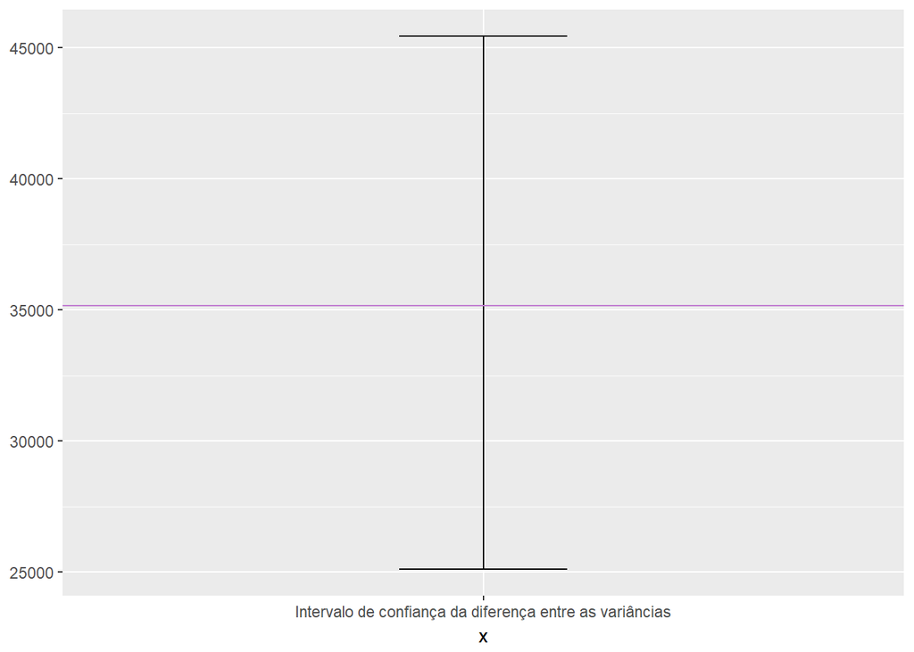

```r
c <- dados %>% filter(file_extension == "c")

var_c <- bootstrap2(c$users,
                         treatment = c$weekend,
                         var,
                         R = 15000)

var_c_ci <- CI.percentile(var_c, probs = c(.025, .975))

data.frame(var_c_ci) %>%
  ggplot() +
  geom_errorbar(aes(x = "Intervalo de confiança da diferença entre as variâncias", ymin = X2.5., ymax = X97.5.), width = .2) +
  geom_hline(yintercept = 35150.96, colour = "#c17dd1")
```

## Verificando a atividade no período de férias

Na segunda parte da nossa análise será verificado se há alguma mudança na atividade dos usuários em todas as linguagens de programação nos períodos de recesso, como no mês de Julho, Janeiro e Dezembro.

Hipótese: A atividade dos usuários deve cair significativamente nos meses de férias, pois não estariam trabalhando, portanto não devem alterar os seus repositórios com a mesma frequência.

```r
# Separar os dados em meses de férias ou não

dados$holidays = dados$the_month %in% c(1,7, 12)

p2 <- dados %>% ggplot(aes(x=holidays, y=users, fill = holidays )) + geom_boxplot(outlier.shape = NA) + labs(title = "Boxplot da Atividade de usuários", x = "Férias", y = "Usuários", fill= "Férias") + scale_fill_manual(values=c("#59a56a", "#5dbbbf"))



ggplotly(p2,width = 800,height = 500)
```

```
## We recommend that you use the dev version of ggplot2 with `ggplotly()`
## Install it with: `devtools::install_github('hadley/ggplot2')`
```

[interactive chart not shown]

Pelos boxplots é possível observar que a diferença entre o comportamento das atividades dos usuários é mínima, sendo até irrelevante, as medianas das atividades são praticamente iguais, para confirmar essa conclusão usaremos o bootstrap novamente.

### Calculando a diferença entre as medianas com bootstrap

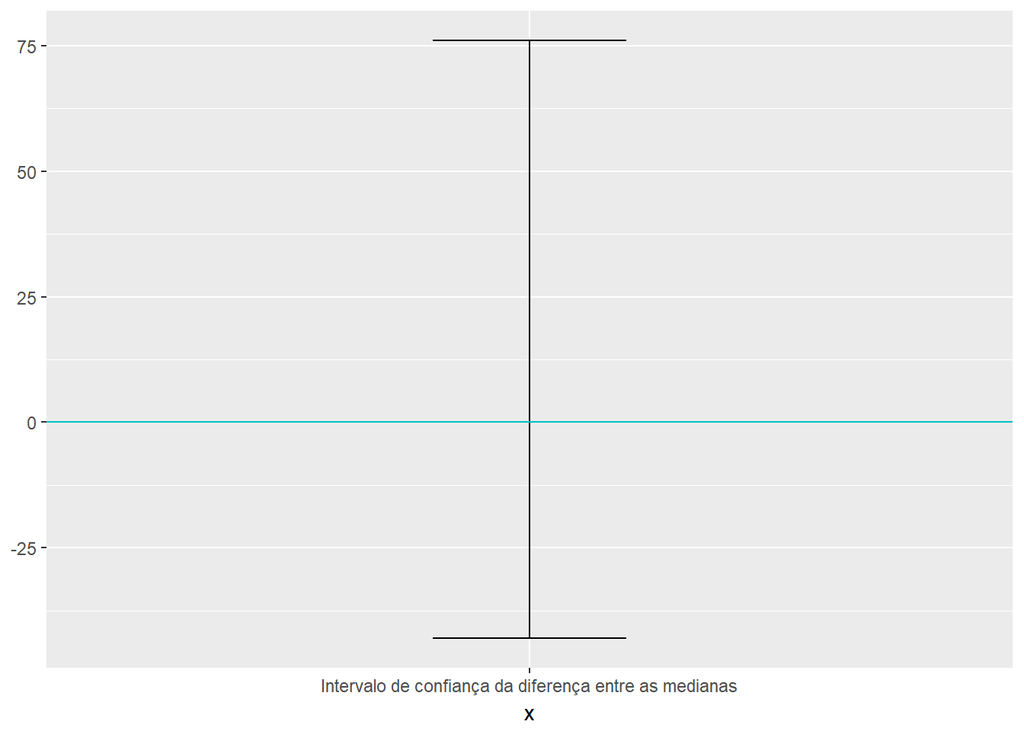

```r
median_holidays <- bootstrap2(dados$users,
                         treatment = dados$holidays,
                         median,
                         R = 15000)

median_holidays_ci <- CI.percentile(median_holidays, probs = c(.025, .975))


data.frame(median_holidays_ci) %>%
  ggplot() +
  geom_errorbar(aes(x = "Intervalo de confiança da diferença entre as medianas", ymin = X2.5., ymax = X97.5.), width = .2) +
  geom_hline(yintercept = 0, colour = "#00bfc4")
```

Podemos observar que o intervalo de confiança da diferença entre as medianas das atividades nos meses sem férias e com férias é [-43, 76] (com 95% de confiança) dessa forma vemos que a diferença não é significativa, e que há chances dos meses com férias terem atividade um pouco maior do que os meses sem. Portanto concluimos que a hipótese levantada é nula.

## Segunda Hipótese

Levamos em consideração os meses de Janeiro, Julho e Dezembro, porém Julho são férias escolares, não é todo mundo que trabalha que tira férias nesse mês, portanto foi especulado que ele poderia estar interferindo com os resultados, já que Dezembro e Janeiro são os meses em que realmente todos (estudantes e trabalhadores) tem pelo menos alguns dias de folga.

Hipótese: A atividade dos usuários deve cair pelo menos um pouco em dezembro e janeiro, pois são os meses onde há recesso para todos.

```r
dados$holidays = dados$the_month %in% c(1, 12)

p2 <- dados %>% ggplot(aes(x=holidays, y=users, fill = holidays )) + geom_boxplot(outlier.shape = NA) + labs(title = "Boxplot da Atividade de usuários", x = "Férias", y = "Usuários", fill= "Férias")

ggplotly(p2,width = 800,height = 500)
```

```
## We recommend that you use the dev version of ggplot2 with `ggplotly()`
## Install it with: `devtools::install_github('hadley/ggplot2')`
```

[interactive chart not shown]

É visto que não há nenhuma mudança significativa entre o gráfico acima e o anterior (com Julho incluso), portanto anula-se a hipótese. No entanto isso será confirmado com o uso de bootstrap.

### Calculando a diferença entre as medianas com bootstrap

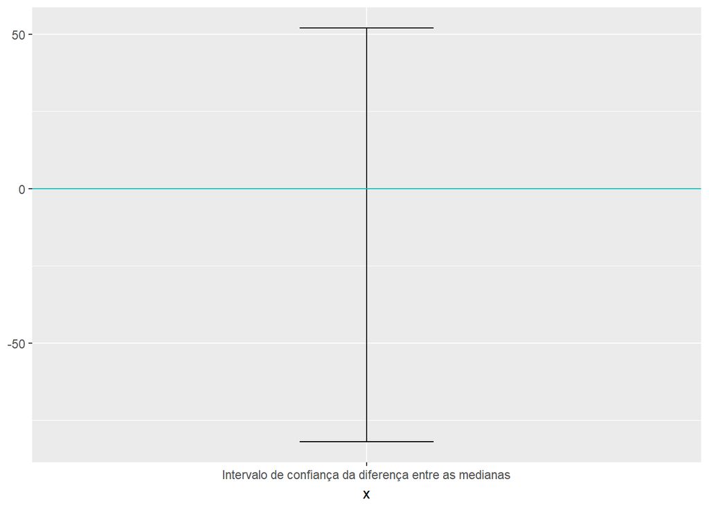

```r
median_holidays <- bootstrap2(dados$users,
                         treatment = dados$holidays,
                         median,
                         R = 15000)

median_holidays_ci <- CI.percentile(median_holidays, probs = c(.025, .975))


data.frame(median_holidays_ci) %>%
  ggplot() +
  geom_errorbar(aes(x = "Intervalo de confiança da diferença entre as medianas", ymin = X2.5., ymax = X97.5.), width = .2) +
  geom_hline(yintercept = 0, colour = "#00bfc4")
```

Podemos observar que o intervalo de confiança da diferença entre as medianas das atividades nos meses sem férias e com férias é [-84, 50] (com 95% de confiança) dessa forma vemos que a diferença teve uma leve mudança, porém não foi o que era esperado, há agora mais chances dos meses com férias terem atividade um pouco maior do que os meses sem, no entanto a diferença continua sendo irrelevante. Dessa maneira temos que a hipótese é nula, a atividade dos usuários no github não apresenta diferenças significantes entre o periodo letivo e o de recesso.